# **Density Dependence**

Mackerel: density dependence in mass, maturity and M-at-age

L Kell

09 February, 2023

Life history parameters are used to develop an example of modelling density dependence for mass, maturity and natural mortality-at-age. The parameters are first used to construct An `FLBRP` object representing the equilibrium, and are then coerced into an `FLStock` to model the time series dynamics.

### Mass-at-age

Mass-at-age ($W_a$) is modelled as

$W_a = {\overline{W_a}} B^{{\beta}_a}$

Where $\overline{W_a}$ and $\beta$ are estimated from a regression of mass-at-age ($W_a$) on total biomass ($B_a$), based on empirical data. $W_a$ is constrained so sizes do not become unfeasible large or small.

### Maturity-at-weight

Maturity is then modelled as a logistic function of mass-at-age i.e.

$O(W_a) = 1/(1+e^{k(W_a-W_{50})})$

### Natural mortality

Is assumed to vary at unit length ($L_1$) e.g.

$ln(M_1) =\alpha + \beta ln(L_{\infty}) + \gamma ln(k)$

where $\alpha=0.65$, $\beta=0.91$, $\gamma=0.87$

Length-at-age ($L_a$) can be obtained from the length-weight relationship

$L_a=(W/a)^{1/b}$

giving

$ln(M_1) =(W/a)^{1/b}(\alpha + \beta ln(L_{\infty}) + \gamma ln(k))$

For DD there is a relationship between $M_a$ and total biomass ($B$)

Mackerel:

$M = 0.0232B + 0.0524$

Blue whiting:

$M = 0.0221B + 0.0719$

Combining these provides values of $M_a$

[output not shown]

# Simulations

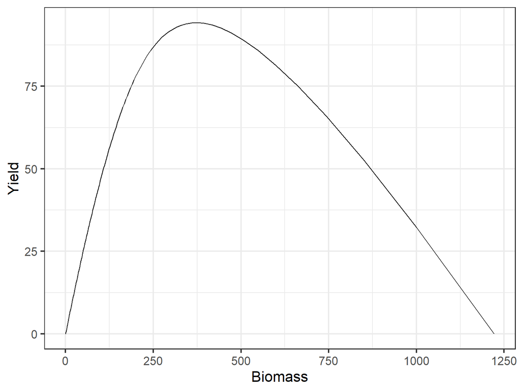

**Figure 1** Yield v Biomass at equilibrium

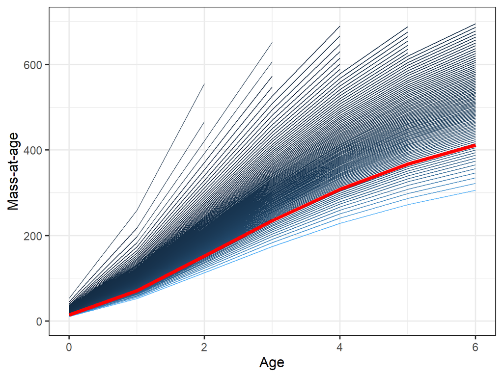

**Figure 2** Simulation of density dependence in mass-at-age

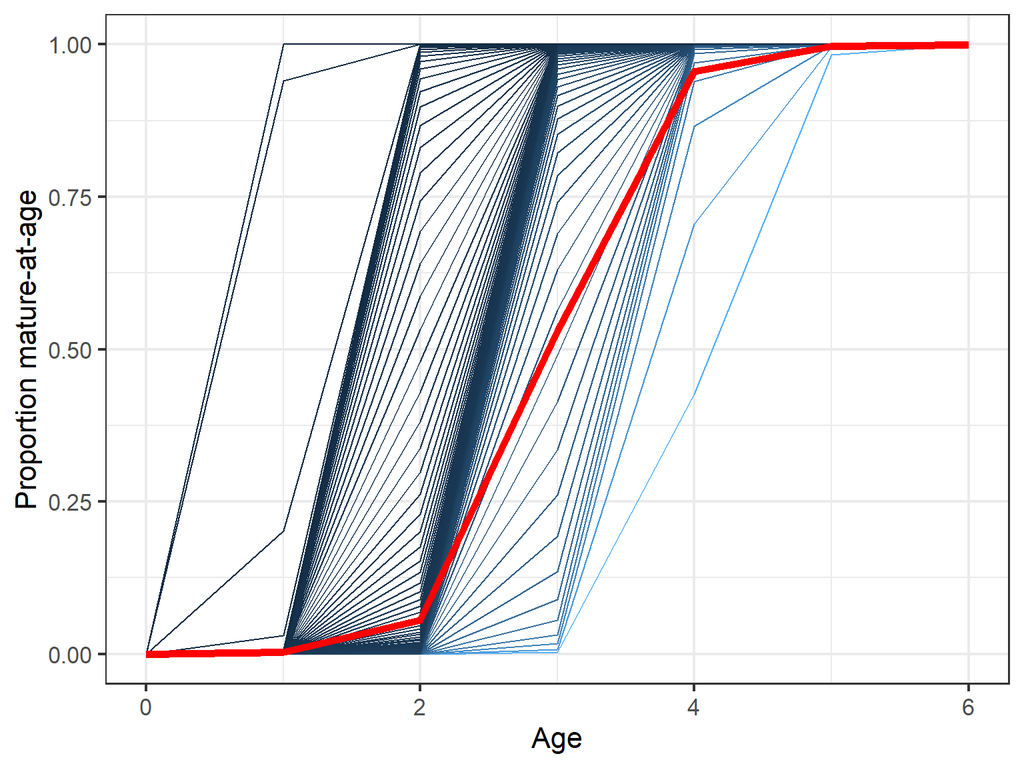

**Figure 3** Simulation of density dependence in maturity-at-age

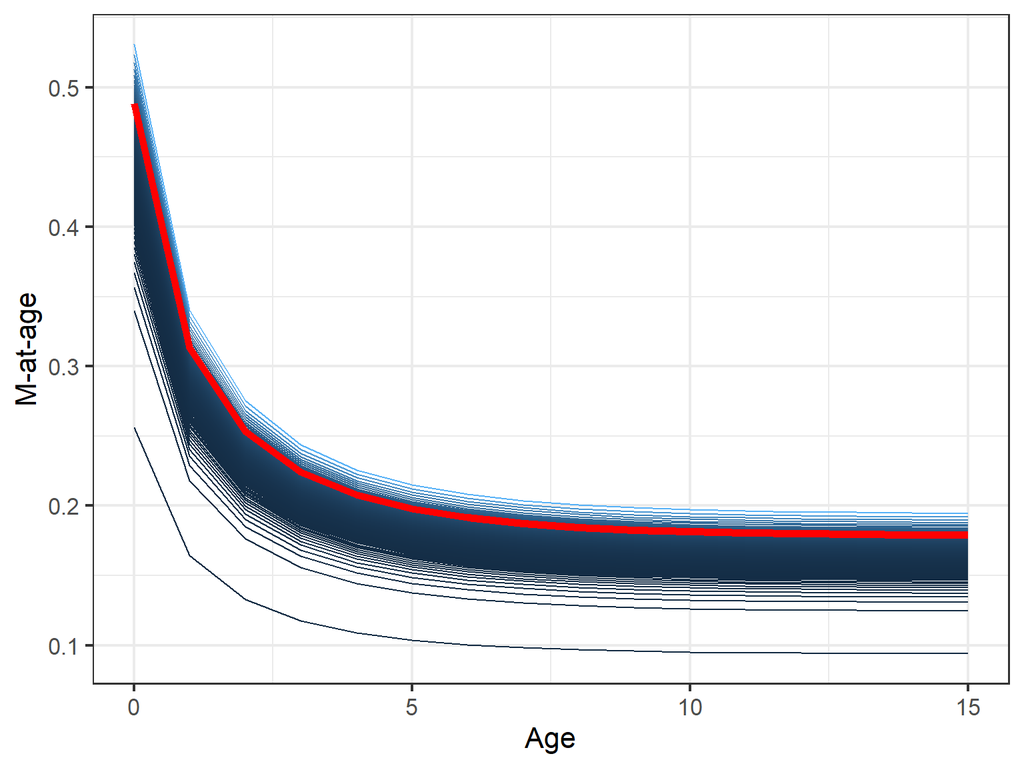

**Figure 4** Lorenzen: Simulation of density dependence in M-at-age

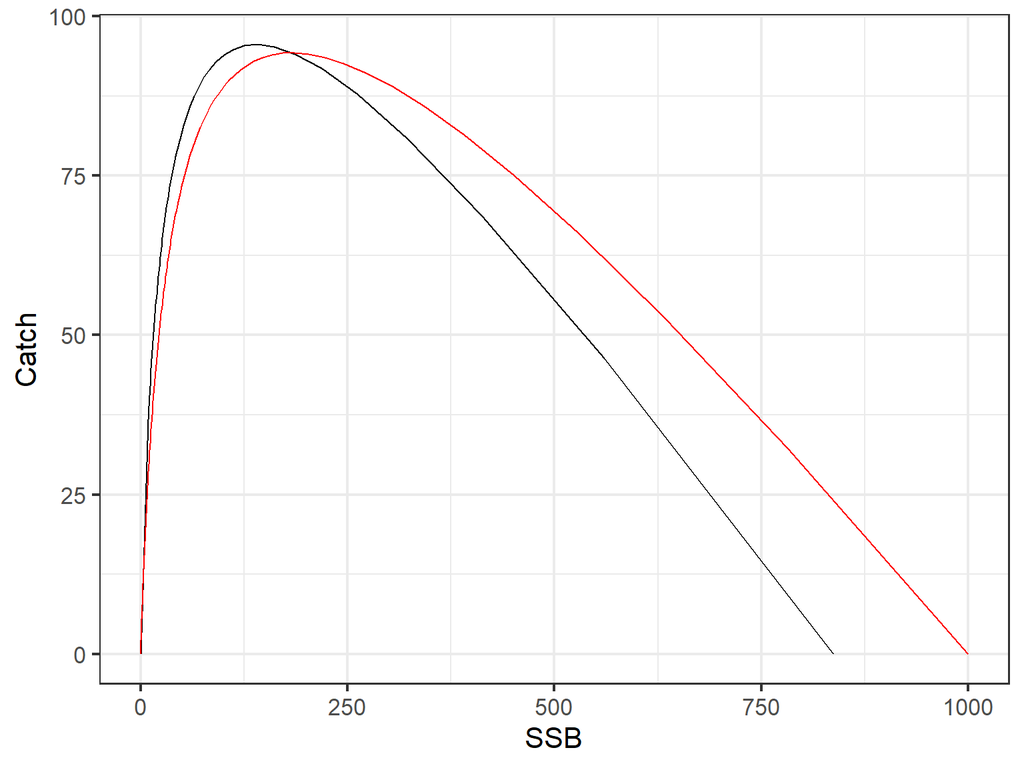

**Figure 5** Mass-at-age: Comparison of equilibrium curves with (black) and without (red) density dependence.

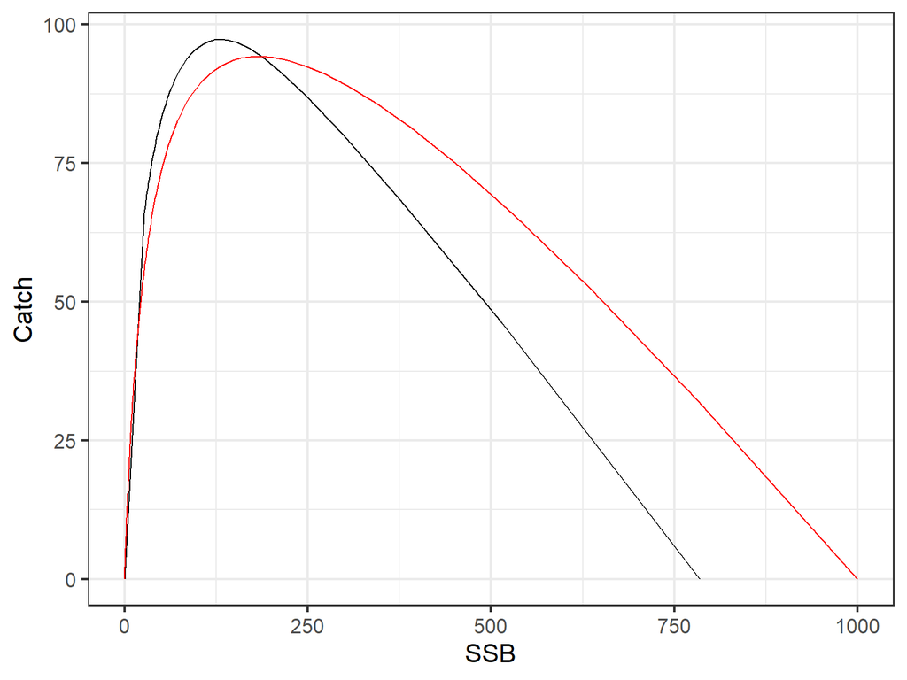

**Figure 6** Mass and maturity-at-age: Comparison of equilibrium curves with (black) and without (red) density dependence.

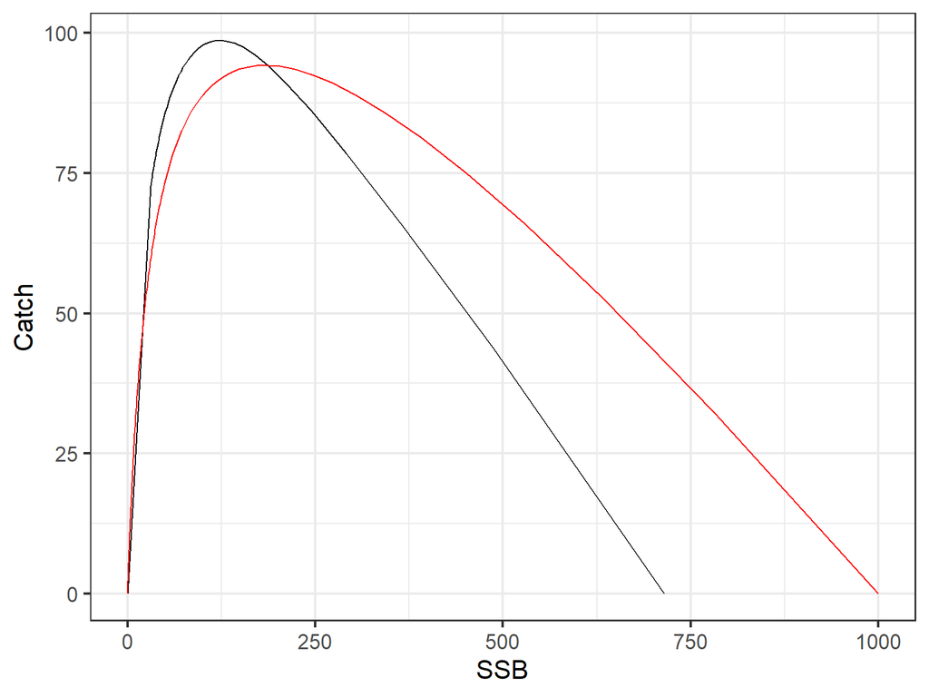

**Figure 7** Mass, maturity and M-at-age: Comparison of equilibrium curves with (black) and without (red) density dependence.

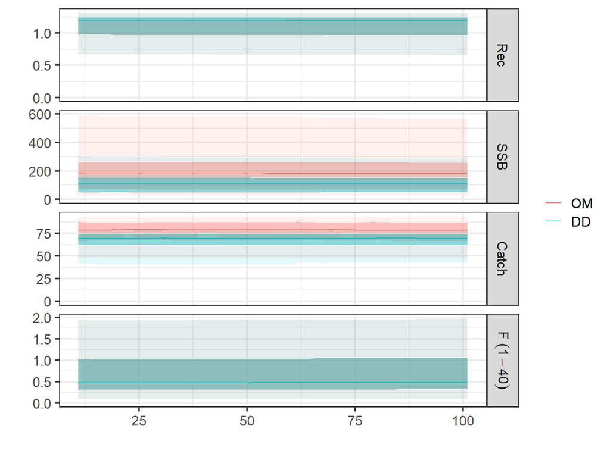

**Figure 8** Check 1.

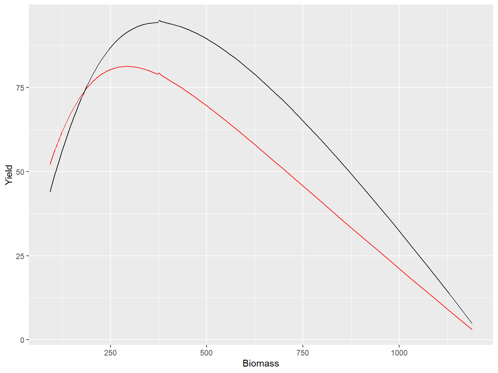

**Figure 9** Check 2.

I think we need 4 OMs and 2 MPs

```
OMs are
    OM with no DD,
    DD in mass,
    DD in mass + mat,
    DD in mass, mat + m
MPs are HCR with
    refpts without DD (i.e. OM 1) and
    same as OM (for 2,3&4)
```

So we match/mismatch, in that we get the DD hypothesis right or use current practice

We condition all the OMs for M-at-age varying, and reported catch. An issue is the short-cut since if we assume no DD in the MP but there is DD in the OM we have to replicate the bias.

The remaining issue is random variation in recs, mass etc.

# References